# Self Regulation Ontology Retest Data: Initial Exploration

Load original data

```r
test_data <- read.csv('/Users/zeynepenkavi/Documents/PoldrackLabLocal/Self_Regulation_Ontology/Data/Complete_01-31-2017/variables_exhaustive.csv')
```

Load retest data

```r
retest_data <- read.csv('/Users/zeynepenkavi/Documents/PoldrackLabLocal/Self_Regulation_Ontology/Data/Retest_02_11_2017/variables_exhaustive.csv')
```

[output not shown]

Quick check to make sure there isn’t anything weird with anonymization of retest data

```r
old_lookup2[old_lookup2$complete == 1, 'worker_id'] == last_lookup[1:113, 'worker_id']
```

```
  [1] TRUE TRUE TRUE TRUE TRUE TRUE TRUE TRUE TRUE TRUE TRUE TRUE TRUE TRUE TRUE
 [16] TRUE TRUE TRUE TRUE TRUE TRUE TRUE TRUE TRUE TRUE TRUE TRUE TRUE TRUE TRUE
 [31] TRUE TRUE TRUE TRUE TRUE TRUE TRUE TRUE TRUE TRUE TRUE TRUE TRUE TRUE TRUE
 [46] TRUE TRUE TRUE TRUE TRUE TRUE TRUE TRUE TRUE TRUE TRUE TRUE TRUE TRUE TRUE
 [61] TRUE TRUE TRUE TRUE TRUE TRUE TRUE TRUE TRUE TRUE TRUE TRUE TRUE TRUE TRUE
 [76] TRUE TRUE TRUE TRUE TRUE TRUE TRUE TRUE TRUE TRUE TRUE TRUE TRUE TRUE TRUE
 [91] TRUE TRUE TRUE TRUE TRUE TRUE TRUE TRUE TRUE TRUE TRUE TRUE TRUE TRUE TRUE
[106] TRUE TRUE TRUE TRUE TRUE TRUE TRUE TRUE
```

Extract retest participants

```r
retest_worker_lookup$worker_id %in% test_worker_lookup$worker_id
```

```
  [1]  TRUE  TRUE  TRUE  TRUE  TRUE  TRUE  TRUE  TRUE  TRUE  TRUE  TRUE  TRUE
 [13]  TRUE  TRUE  TRUE  TRUE  TRUE  TRUE  TRUE  TRUE  TRUE FALSE  TRUE  TRUE
 [25]  TRUE  TRUE  TRUE  TRUE  TRUE  TRUE  TRUE  TRUE  TRUE  TRUE  TRUE  TRUE
 [37]  TRUE  TRUE  TRUE  TRUE  TRUE  TRUE  TRUE  TRUE  TRUE  TRUE  TRUE  TRUE
 [49]  TRUE  TRUE  TRUE  TRUE  TRUE  TRUE  TRUE  TRUE  TRUE  TRUE  TRUE  TRUE
 [61]  TRUE  TRUE  TRUE  TRUE  TRUE  TRUE  TRUE  TRUE  TRUE  TRUE  TRUE  TRUE
 [73]  TRUE  TRUE  TRUE  TRUE  TRUE  TRUE  TRUE  TRUE  TRUE  TRUE  TRUE  TRUE
 [85]  TRUE  TRUE  TRUE  TRUE  TRUE  TRUE  TRUE  TRUE  TRUE  TRUE  TRUE  TRUE
 [97]  TRUE  TRUE  TRUE  TRUE  TRUE  TRUE  TRUE  TRUE  TRUE  TRUE  TRUE  TRUE
[109]  TRUE  TRUE  TRUE  TRUE  TRUE  TRUE  TRUE  TRUE  TRUE  TRUE  TRUE  TRUE
[121]  TRUE  TRUE  TRUE  TRUE  TRUE  TRUE  TRUE  TRUE  TRUE  TRUE  TRUE  TRUE
[133]  TRUE  TRUE  TRUE  TRUE  TRUE  TRUE  TRUE  TRUE  TRUE  TRUE  TRUE  TRUE
[145]  TRUE  TRUE  TRUE
```

One retest participant is not in test data. Remove that subject from lookup table and from retest_data

```r
retest_worker_lookup <- retest_worker_lookup[retest_worker_lookup$worker_id %in% test_worker_lookup$worker_id,]

retest_data <- retest_data[retest_data$sub_id %in% retest_worker_lookup$sub_id,]
```

Id match df

| worker_id | retest_sub_id | test_sub_id |
| --- | --- | --- |
| A100Y89FZO4J0B | s139 | s198 |
| A11UQWFUDNIHIL | s090 | s409 |
| A1295RHU5X5GTX | s089 | s473 |
| A12DBV9FNAOFEM | A12DBV9FNAOFEM | s286 |
| A12FCLCVIM2CL3 | s133 | s017 |
| A1489QNXV5IM6O | s054 | s092 |
| A14I3K8UN3612X | s094 | s403 |
| A1640H4RXH8NZE | s145 | s103 |
| A16UAN46CNIRHY | s051 | s081 |
| A173LV77LF3SHB | s113 | s357 |

[output cut: 136 more lines]

Extract test data for retest subjects, add worker_id column to both datasets and arrange by worker_id, check if the rows match

```r
test_data$worker_id == retest_data$worker_id
```

```
  [1] TRUE TRUE TRUE TRUE TRUE TRUE TRUE TRUE TRUE TRUE TRUE TRUE TRUE TRUE TRUE
 [16] TRUE TRUE TRUE TRUE TRUE TRUE TRUE TRUE TRUE TRUE TRUE TRUE TRUE TRUE TRUE
 [31] TRUE TRUE TRUE TRUE TRUE TRUE TRUE TRUE TRUE TRUE TRUE TRUE TRUE TRUE TRUE
 [46] TRUE TRUE TRUE TRUE TRUE TRUE TRUE TRUE TRUE TRUE TRUE TRUE TRUE TRUE TRUE
 [61] TRUE TRUE TRUE TRUE TRUE TRUE TRUE TRUE TRUE TRUE TRUE TRUE TRUE TRUE TRUE
 [76] TRUE TRUE TRUE TRUE TRUE TRUE TRUE TRUE TRUE TRUE TRUE TRUE TRUE TRUE TRUE
 [91] TRUE TRUE TRUE TRUE TRUE TRUE TRUE TRUE TRUE TRUE TRUE TRUE TRUE TRUE TRUE
[106] TRUE TRUE TRUE TRUE TRUE TRUE TRUE TRUE TRUE TRUE TRUE TRUE TRUE TRUE TRUE
[121] TRUE TRUE TRUE TRUE TRUE TRUE TRUE TRUE TRUE TRUE TRUE TRUE TRUE TRUE TRUE
[136] TRUE TRUE TRUE TRUE TRUE TRUE TRUE TRUE TRUE TRUE TRUE
```

Drop columns from original data that are not in retest data

Retest data columns that are not in the original data:

```r
names(retest_data)[names(retest_data) %in% names(test_data) == FALSE]
```

```
[1] "time_perspective_survey.future"
```

Test data columns that are not in the retest data: (as expected; three by two is not added yet)

```r
names(test_data)[names(test_data) %in% names(retest_data) == FALSE]
```

[output not shown]

Datasets with only matching columns

```r
all_columns <- unique(c(names(test_data), names(retest_data)))

matching_columns <- c()
for(i in 1:length(all_columns)){
  if(all_columns[i] %in% names(test_data) & all_columns[i] %in% names(retest_data)){
    matching_columns <- c(matching_columns, all_columns[i])
  }
}

matching_retest_data <- retest_data[,matching_columns]
matching_test_data <- test_data[,matching_columns]
```

Get list of test retest correlations

TODO: write a nicer of getting rid of non numeric columns

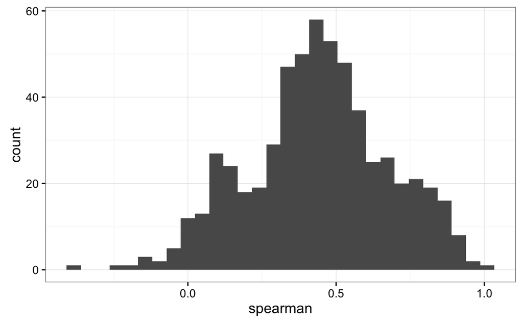

Completion times/days

- First data release email esp to ASU
- Send the spreadsheet with meaningul variables + demographics
- Fix the worker id’s not sharing

Rank order correlations Separately for tasks vs. surveys Mean reliabilities for different kinds of variables (e.g. drift rates and NDs; separately for EX and HDDM; subtraction vs basic variables - single vs. multiple) Can you get the factor structure for the retest step 1:Ttest on all measures of T1 for people w and without retest step2 : efa on the people you don’t have retest on and then predict how well this holds up for people w retest on t1 and on t2 T1 comparison for people who came back vs didn’t (of all that are invited)